# Tutorial 08 — Multi-Strain Dynamics and Named Strains

**Prerequisites:** Tutorials 01–07

All previous tutorials used a single bacterial strain. Real infections involve multiple genotypes with different phage susceptibilities and antibiotic tolerances. This tutorial introduces three ways to configure multi-strain models, ranging from quick manual setup to named clinical strains.

**What you will learn**

1. When to use `ModelBuilder` (prototype) vs `StrainSet` (named strains) vs `BinaryResistanceGenotypes` (systematic genotypes — covered in Tutorial 09)
2. Mutation matrices: sign convention, mass conservation, `gen_mat_from_graph`
3. The `phage_resistance_rates` shortcut for simple binary-genotype models
4. `StrainSet` + `StrainDefinition` for strains with distinct antibiotic profiles
5. `plot_strains` — per-strain dynamics and composition

## 1 Imports

```python
import numpy as np
import matplotlib.pyplot as plt

from pbisim import (ModelBuilder, PBIModel, solve_ode,
                    DoseEvent, DoseSchedule)
from pbisim.strains import StrainDefinition, StrainSet
from pbisim.pk.antibiotic import AntibioticDefinition, AntibioticSensitivity
from pbisim.population.mutation import gen_mat_from_graph, create_mutation_graph
from pbisim.analysis.single import plot_strains

T_END = 72.0
```

## 2 Two-strain model with `ModelBuilder` (prototype)

The simplest multi-strain setup: wild-type (WT) susceptible to phage, and a phage-resistant mutant (R) that pays a fitness cost (lower growth rate).

**Mutation matrix convention:**

- `M[dest, origin] > 0` — flow rate from strain `origin` into strain `dest`
- `M[origin, origin] < 0` — total outflow rate from `origin` (diagonal)
- The diagonal must equal minus the sum of all outgoing off-diagonal rates **(mass conservation: no bacteria are created or destroyed by mutation)**

WT → R at rate μ: `M = [[-μ, 0], [μ, 0]]`

The `phage_resistance_rates` shortcut builds this matrix automatically for binary resistance genotypes (n_bacteria = 2^n_phages).

```
Mutation matrix  (M[dest, origin]):
[[-0.  0.]
 [ 0.  0.]]

Diagonal = [-1.e-07  0.e+00] (negative = mass conserved)
```

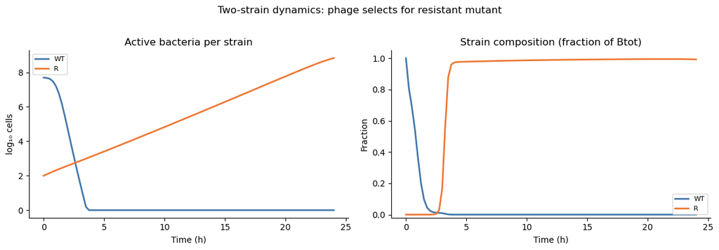

```python
MU = 1e-7   # mutation rate  WT → R  per replication

cfg_two = (
    ModelBuilder(n_bacteria=2, n_phages=1, n_latent=5)
    .with_growth_rates([1.0, 0.92])            # R pays 8% fitness cost
    .with_phage_params(
        adsorption_rates=np.array([[2e-9], [2e-11]]),  # R: 100× lower susceptibility
        adsorption_rates_dormant=np.array([[2e-11], [2e-13]]),
        burst_sizes=50.0, latent_periods=0.5,
        phage_decay_rates=0.1,
    )
    .with_mutations(phage_resistance_rates=[MU])   # auto-builds mass-conserving matrix
    .with_nutrient(monod_constant=0.3, recycle_fraction=0.0)
    .with_dose_schedule(DoseSchedule([
        DoseEvent(time=0, amount=5e8, target="phage", index=0),
    ]))
    .build()
)

# Verify mutation matrix (should have negative diagonal)
M = cfg_two.mutation_rates
print("Mutation matrix  (M[dest, origin]):")
print(np.array2string(M, precision=1, suppress_small=True))
print(f"\nDiagonal = {np.diag(M)} (negative = mass conserved)")

res_two = solve_ode(
    PBIModel(cfg_two, initial_B=np.array([5e7, 1e2]),
             initial_P=np.array([0.0]), initial_S=1.0),
    t_end=24.0, dt=0.25,
)
fig, axes = plot_strains(res_two, strain_labels=["WT", "R"])
plt.suptitle("Two-strain dynamics: phage selects for resistant mutant", y=1.02)
plt.tight_layout()
plt.show()
```

## 3 Custom mutation graphs with `gen_mat_from_graph`

For models with more than two strains or asymmetric mutation rates, build the graph explicitly. `gen_mat_from_graph` handles the diagonal automatically.

**Example:** WT → R1 (phage 0 resistant) and WT → R2 (phage 1 resistant) but R1 → R1+R2 is blocked (e.g., fitness valley — Tutorial 10 covers this).

```python
# 3 strains: WT, R1, R2 (no double-resistant possible from this graph)
graph = {
    "WT": {"R1": 1e-7, "R2": 5e-8},   # WT can acquire either resistance
    "R1": {},                            # R1 cannot progress further
    "R2": {},                            # R2 cannot progress further
}
states = ["WT", "R1", "R2"]
M3 = gen_mat_from_graph(states, graph)
print("3-strain mutation matrix:")
print(np.array2string(M3, precision=1, suppress_small=True))
```

```
3-strain mutation matrix:
[[-0.  0.  0.]
 [ 0.  0.  0.]
 [ 0.  0.  0.]]
```

## 4 Named strains with `StrainSet`

Use `StrainSet` + `StrainDefinition` when strains have **different antibiotic PD profiles** that cannot be expressed as a simple scalar array. This is the right tool for modelling a known clinical isolate panel.

**Scenario:** WT susceptible to both ciprofloxacin and phage. A clinical mutant R_cipro has developed ciprofloxacin resistance (30× higher EC50) but remains phage-susceptible — a classic antibiotic resistance phenotype.

Note that `StrainSet` builds the same `ModelConfig` as `ModelBuilder`; the two approaches are interchangeable at the simulation level.

[figure not shown]

```
Final WT:     1.65e+02 cells/mL
Final R_cipro:5.74e-01 cells/mL
```

```python
# Define antibiotics
cipro = AntibioticDefinition("cipro", k_elim=0.5, Vc=15.0, k12=0.4, k21=0.1)

# Sensitivity objects
CIPRO_S = AntibioticSensitivity(emax=5.0, ec50=0.5)    # susceptible
CIPRO_R = AntibioticSensitivity(emax=5.0, ec50=15.0)   # resistant: 30× higher EC50

ss = StrainSet(n_phages=1)
ss.add_antibiotic(cipro)

# WT — susceptible to both phage and cipro
ss.add_strain(StrainDefinition(
    name="WT",
    growth_rate=1.0,
    adsorption_rates=np.array([2e-9]),
    adsorption_rates_dormant=np.array([2e-11]),
    burst_sizes=np.array([50.0]),
    latent_periods=np.array([0.5]),
    latent_periods_dormant=np.array([1.0]),
    bacteria_to_resource_ratio=1e9,
    dormancy_rate=0.1, resuscitation_rate=0.05, dormancy_diffusion_rate=0.0,
    imm_stim_rate=0.0, imm_kill_rate=0.0, attenuation_rate=np.array([0.0]),
    antibiotic_sensitivity={"cipro": CIPRO_S},
))

# Cipro-resistant mutant — same phage susceptibility, 8% fitness cost
ss.add_strain(StrainDefinition(
    name="R_cipro",
    growth_rate=0.92,
    adsorption_rates=np.array([2e-9]),
    adsorption_rates_dormant=np.array([2e-11]),
    burst_sizes=np.array([50.0]),
    latent_periods=np.array([0.5]),
    latent_periods_dormant=np.array([1.0]),
    bacteria_to_resource_ratio=1e9,
    dormancy_rate=0.1, resuscitation_rate=0.05, dormancy_diffusion_rate=0.0,
    imm_stim_rate=0.0, imm_kill_rate=0.0, attenuation_rate=np.array([0.0]),
    antibiotic_sensitivity={"cipro": CIPRO_R},
))

# Mutation: WT → R_cipro at rate 1e-8
ss.set_mutation_graph({"WT": {"R_cipro": 1e-8}})

cfg_ss = ss.to_config(
    n_latent=5, n_depth=1,
    phage_decay_rates=np.array([0.1]),
    imm_decay_rate=0.1, imm_stim50=1e6, imm_kill50=1e6,
    monod_constant=0.3, recycle_fraction=0.0,
)

# Add combination dosing
dose_combo = DoseSchedule([
    DoseEvent(time=0,  amount=5e8,  target="phage",      index=0),
    DoseEvent(time=0,  amount=400,  target="antibiotic",  index=0),
    DoseEvent(time=12, amount=400,  target="antibiotic",  index=0),
    DoseEvent(time=24, amount=400,  target="antibiotic",  index=0),
    DoseEvent(time=36, amount=400,  target="antibiotic",  index=0),
    DoseEvent(time=48, amount=400,  target="antibiotic",  index=0),
    DoseEvent(time=60, amount=400,  target="antibiotic",  index=0),
])
import dataclasses
cfg_ss_dosed = dataclasses.replace(cfg_ss, dose_schedule=dose_combo)

res_ss = solve_ode(
    PBIModel(cfg_ss_dosed,
             initial_B=np.array([5e7, 1e3]),   # rare resistant mutant pre-exists
             initial_P=np.array([0.0]), initial_S=1.0),
    t_end=T_END, dt=0.25,
)

fig, axes = plot_strains(res_ss, strain_labels=["WT", "R_cipro"])
axes[0].set_title("WT: killed by phage AND cipro")
axes[1].set_title("R_cipro: killed by phage, tolerates cipro (EC50=15)")
plt.suptitle("StrainSet: phage selects WT, cipro selects R_cipro — synergy clears both",
             y=1.02)
plt.tight_layout()
plt.show()

print(f"Final WT:     {res_ss.get('B0')[-1]:.2e} cells/mL")
print(f"Final R_cipro:{res_ss.get('B1')[-1]:.2e} cells/mL")
```

## 5 Decision guide: which builder to use?

```
I want to model...
│
├── 1 strain (tutorials 01–07): ModelBuilder
│
├── Named clinical strains with individual antibiotic sensitivity profiles
│   → StrainSet + StrainDefinition
│
├── All 2^m phage-resistance genotypes (cocktail resistance modelling)
│   → BinaryResistanceGenotypes.from_strains()   [Tutorial 09]
│
└── Quick 2-strain prototype with binary resistance
    → ModelBuilder + .with_mutations(phage_resistance_rates=[μ])
```

All three produce an identical `ModelConfig` — the choice is purely about convenience and how the parameters are organized in your code.

**Next tutorial:** *Binary Resistance Genotypes* — auto-enumerating all 2^m resistance genotypes, systematic cross-resistance, and mutation graph control.